# Part II - (US Flights Delay exploration )

## by (Yaninthé Tiomene)

## Investigation Overview

> In this part of investigation, we will try to answer these questions:
> - What are origins/Destinations with maximum delay / cancelation?
> - Airline with most delay / cancelation?
> - What are the preferred times for flights to occur? Are there any changes over multiple years?

## Dataset Overview

> The dataset that will be used is from [Dataverse](https://dataverse.harvard.edu/dataset.xhtml?persistentId=doi:10.7910/DVN/HG7NV7) and it reports flights in the United States, including carriers, arrival and departure delays from 1987 to 2008. But due to my CPU and GPU capacity, I will only consider data for 2006, and 2007. We could have considered flights data of 2008, but it only has records up to April of 2008, as the hole dataset was published in October of 2008. If we want to compare flights per month or per year the result may be biased. It consists of 14595137 entries and 33 features where majorities are numericals.

## Distribution of departure and arrival delay

> Arrival and Departure delays are mostly located on the left side of the graph, with a long tail to the right. The majority of departure delays are short (earlier flights and departure flights delay between -20 and 70 minutes) , and the longest delays, while unusual, are more heavy loaded in time. ArrDelay is nearest to a normal distribution, but skew to the right.

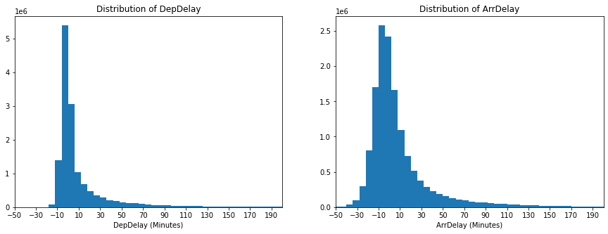

## Correlation between Arrival delay and Departure delay

> ArrDelay and DepDelay are highly correlated with one another. Which is what expected, since a flight which is delayed at departure should normally have a delay at arrival. The higher the delay is at departure, the higher it should be at arrival. We can also see that there are earlier flights in departure (more than 16 hours earlier than scheduled) which are late at arrival (they might be outliers).

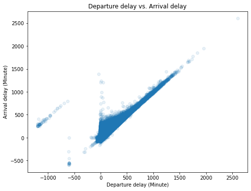

## Number of flight per class Of delay

> Most of the flights (58.3%) departed less than 30 minutes earlier as shceduled and 29.2% departed less than 30 minutes later as scheduled. Most of the flights (52.5%) arrived less than 30 minutes earlier as scheduled and 32.6% arrived less than 30 minutes later as scheduled.

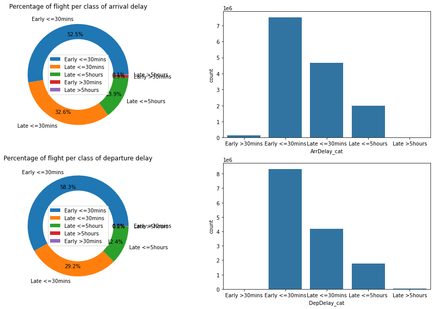

## Top 10 busiest Airport (origin/Destination)

> We have same top 10 busiest airport from origin and destination, with `ATL` being the most busiest one, with more than 800k flights in arrival and same in departure.

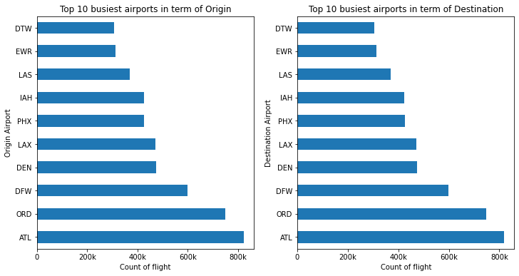

## Airports (Origin/Destination) which are subject to maximum delays

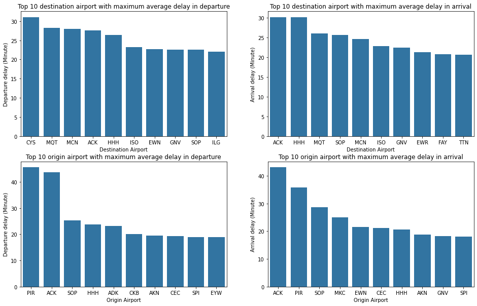

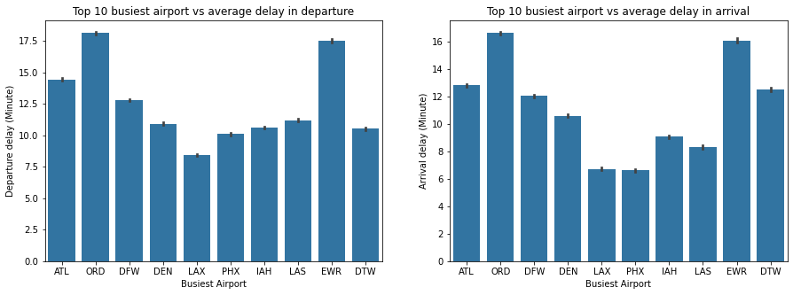